# AtlasVPM: Atlas de Farmacia

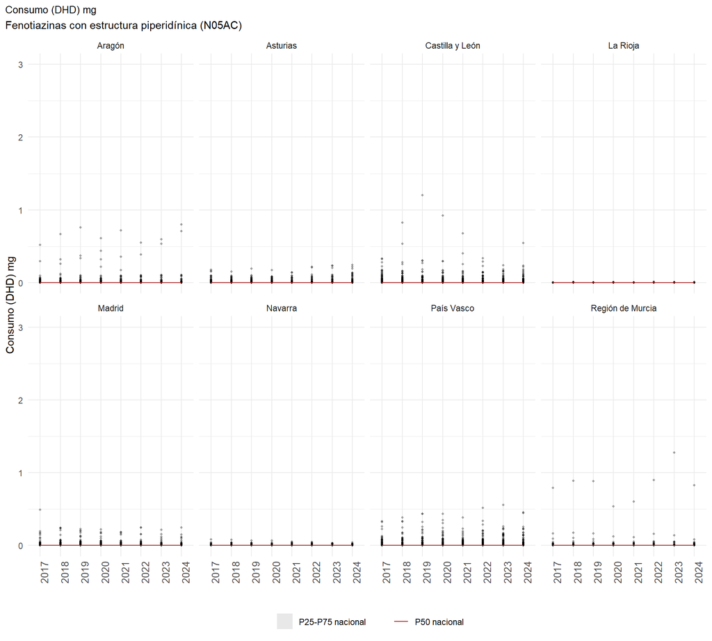

**Derivados de la butirofenona (N05AD)**

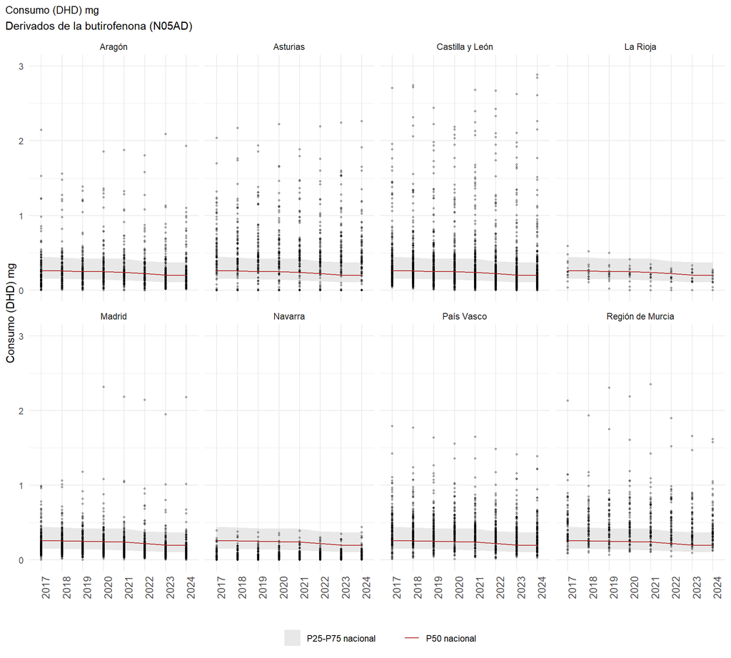

**Derivados del indol (N05AE)**

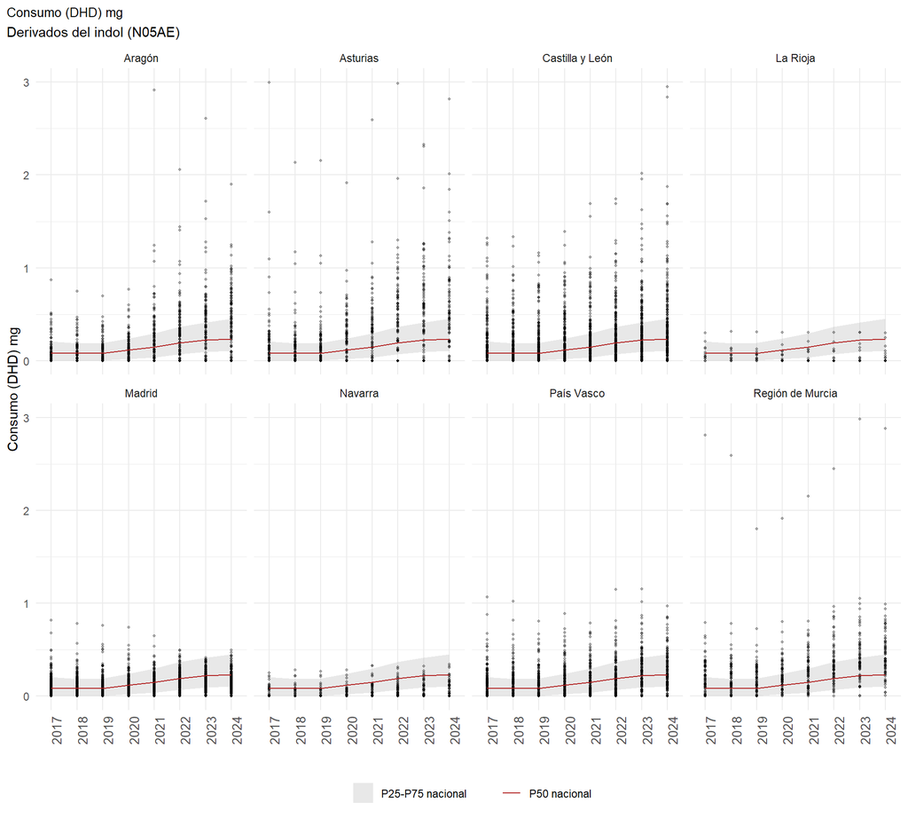

**Derivados del tioxanteno (N05AF)**

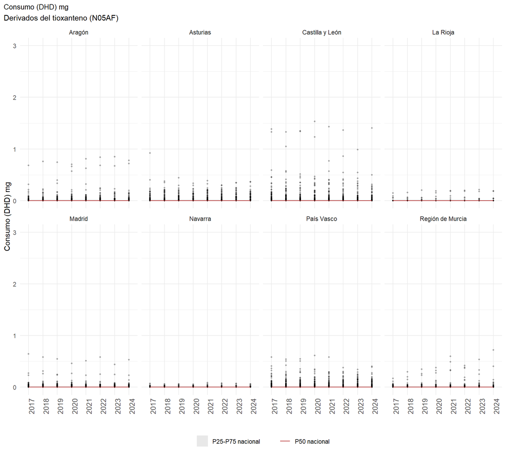

**Derivados del difenilbutilpiperidina (N05AG)**

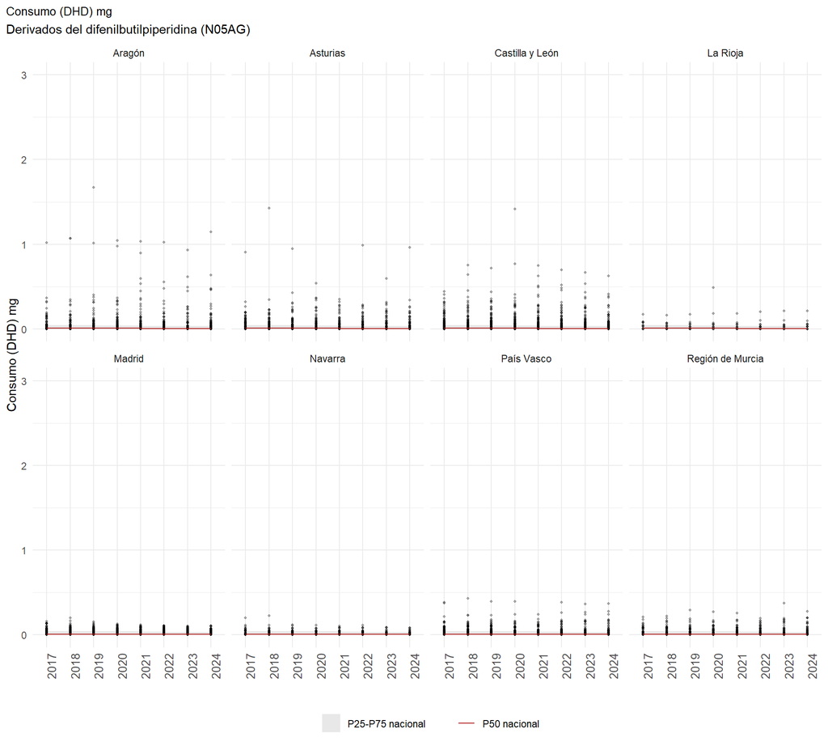

**Diazepinas, oxaxepinas y tiazepinas (N05AH)**

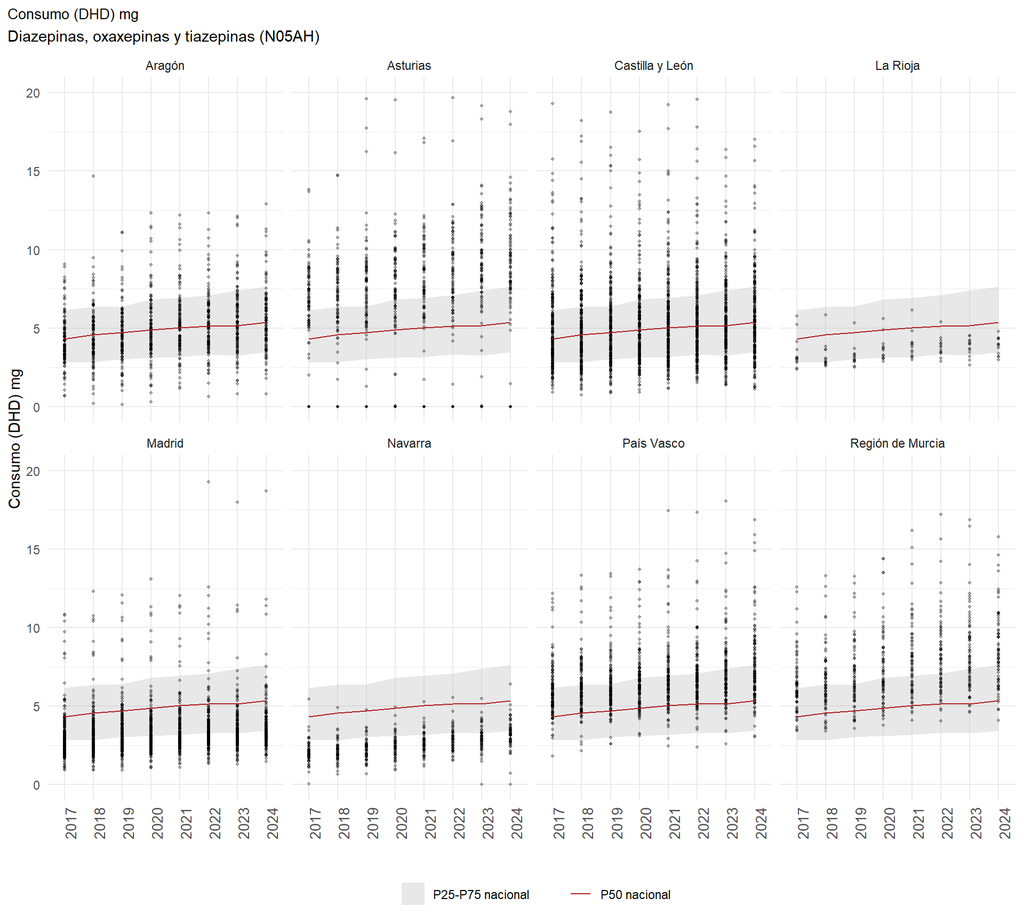

**Benzamidas (N05AL)**

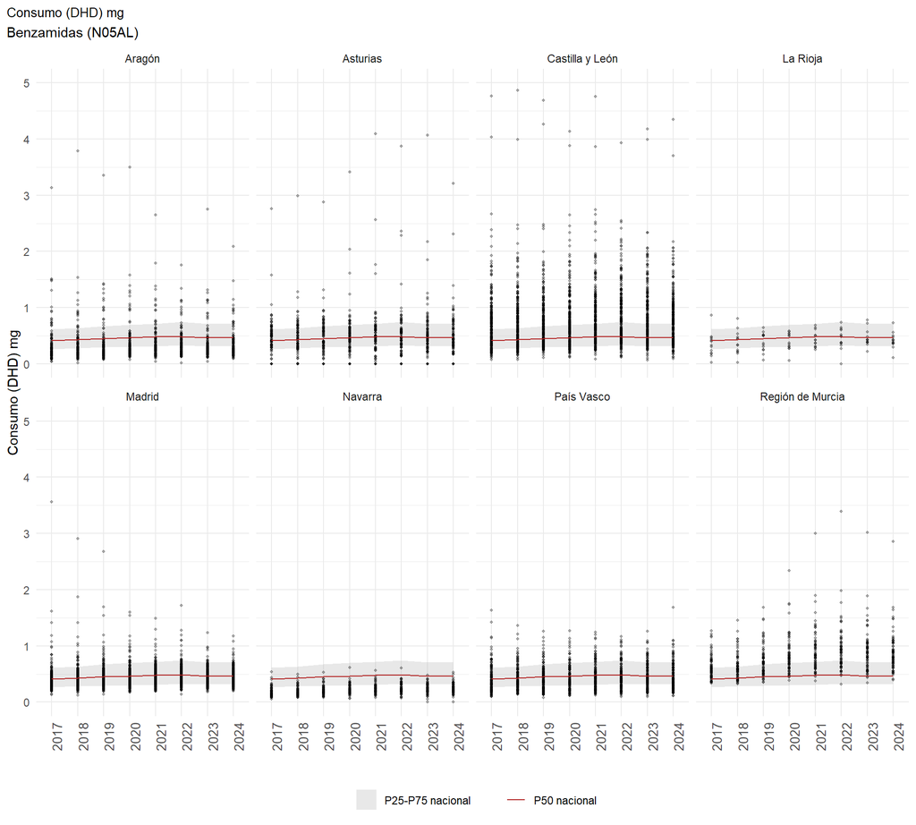

**Otros antipsicóticos (N05AX)**

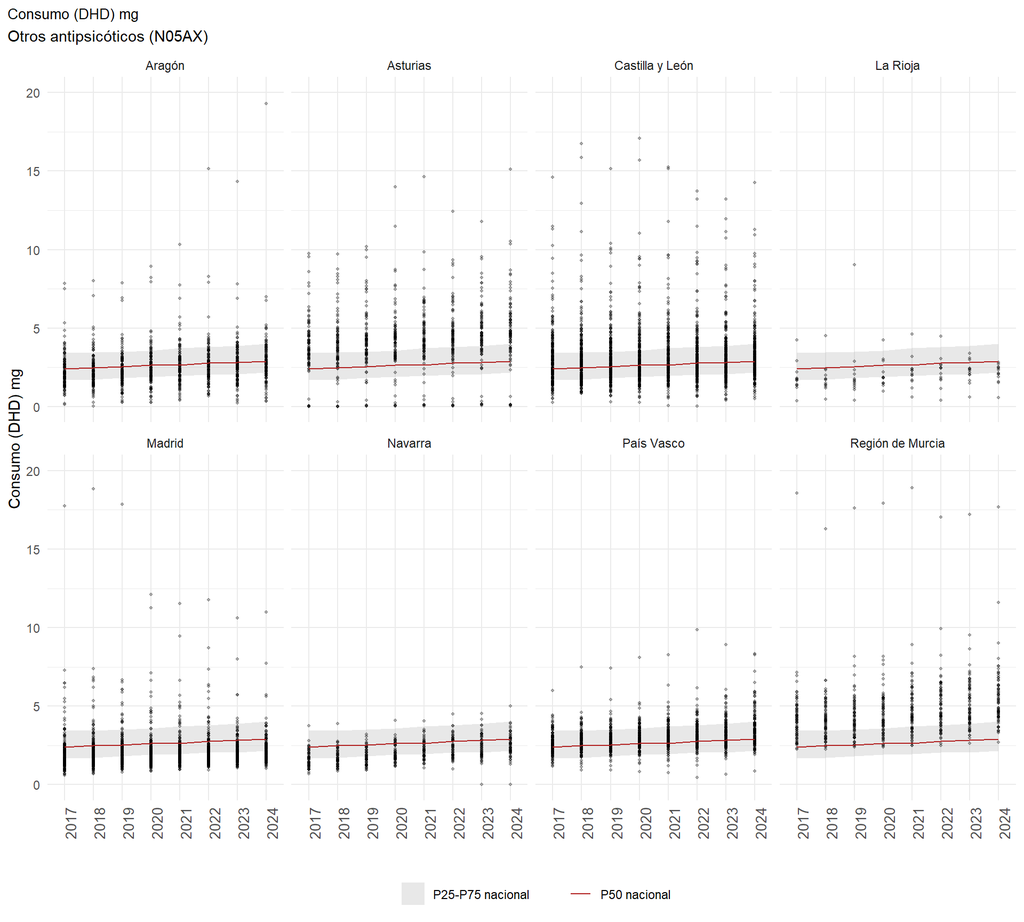

## Variación geográfica de consumo (DHD) de antipsicóticos en el año 2024

**Descripción figura**

Se muestra la variación geográfica mediante mapas por CCAA del consumo (DHD) en las zonas básicas de salud que componen el sistema nacional de salud para el último año disponible. La figura está coloreada por quintiles calculados a nivel nacional.

**Antipsicóticos (N05A)**

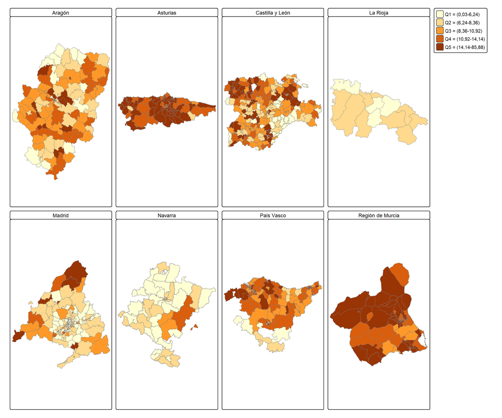

**Fenotiazinas con cadena lateral alifática (N05AA)**

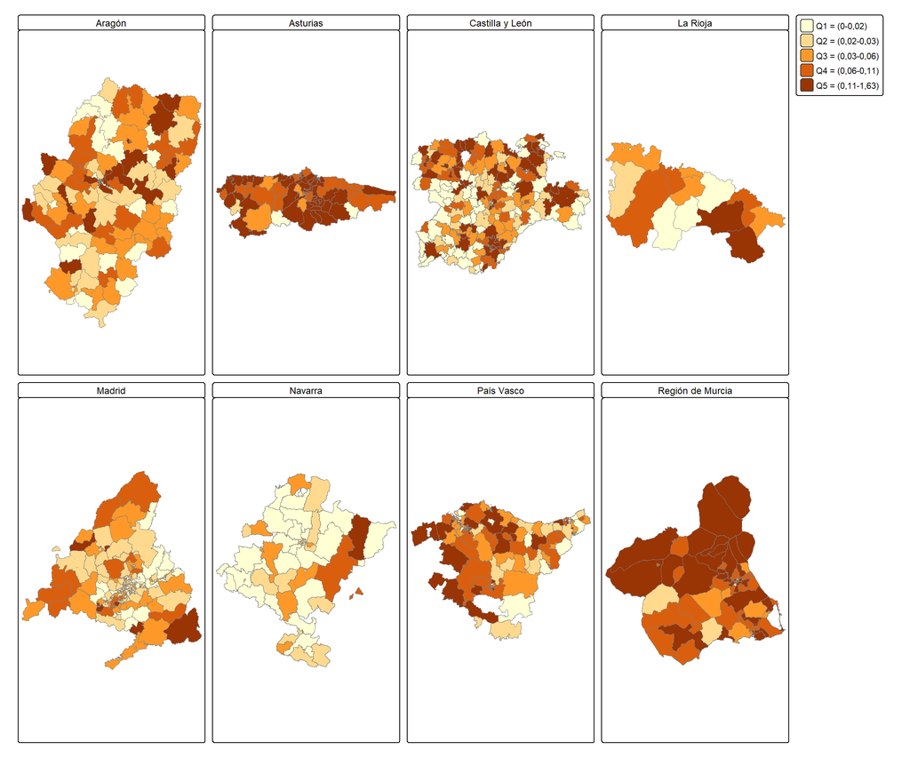

**Fenotiazinas con estructura piperazínica (N05AB)**

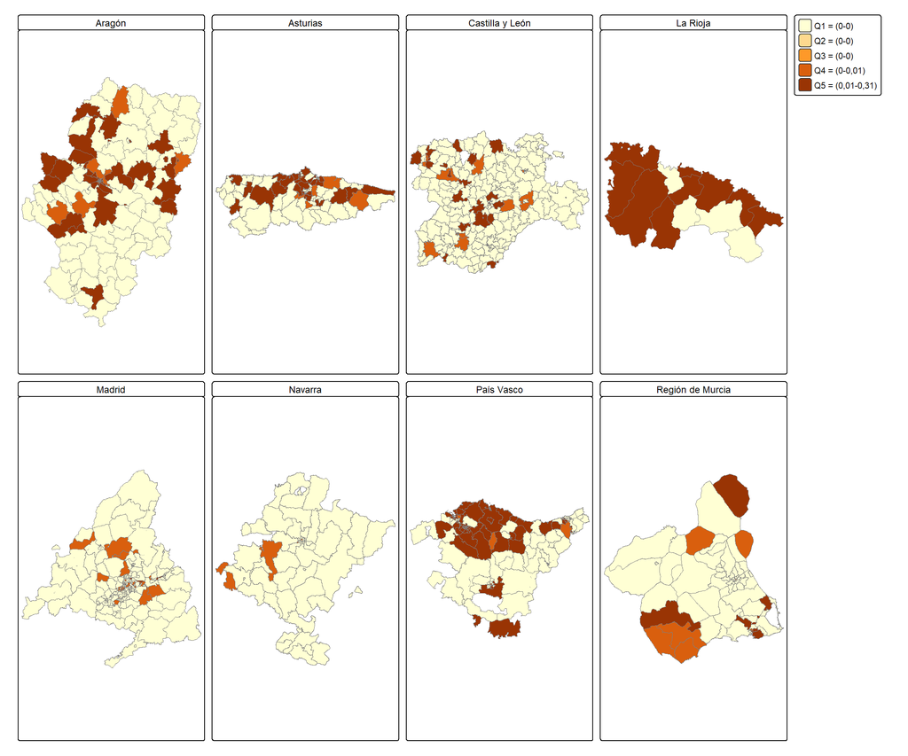

**Fenotiazinas con estructura piperidínica (N05AC)**

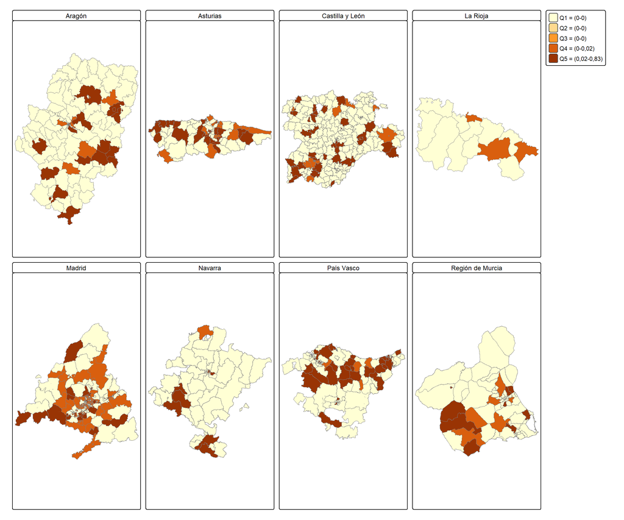

**Derivados de la butirofenona (N05AD)**

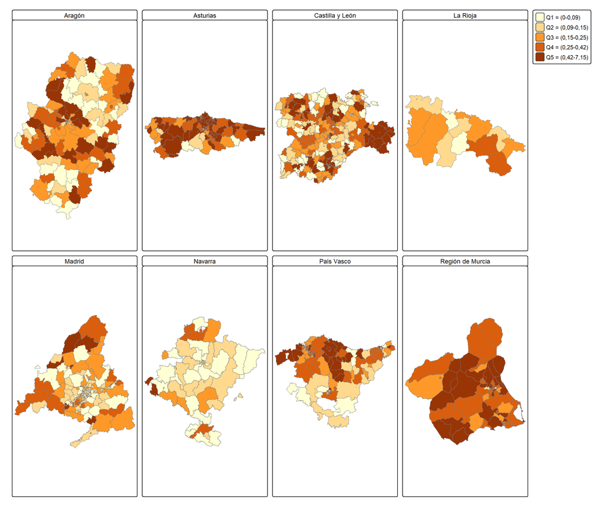

**Derivados del indol (N05AE)**

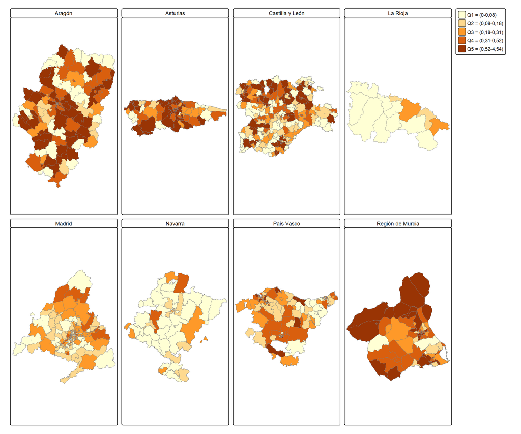

**Derivados del tioxanteno (N05AF)**

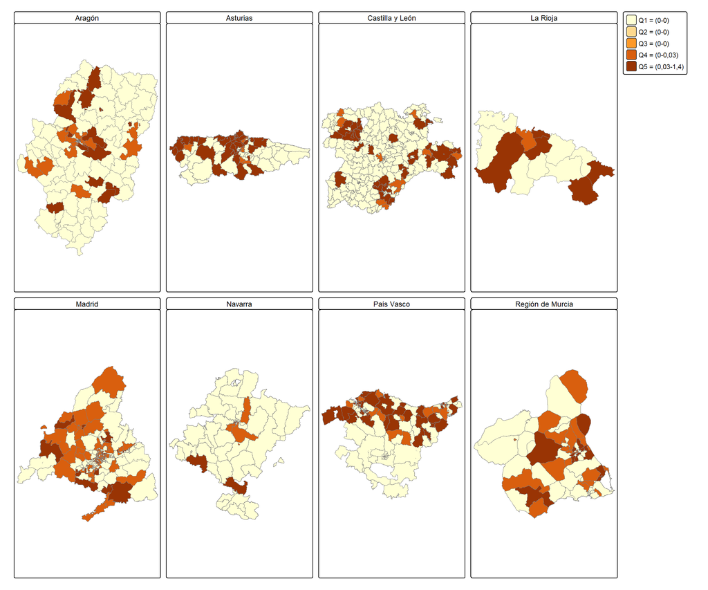

**Derivados del difenilbutilpiperidina (N05AG)**

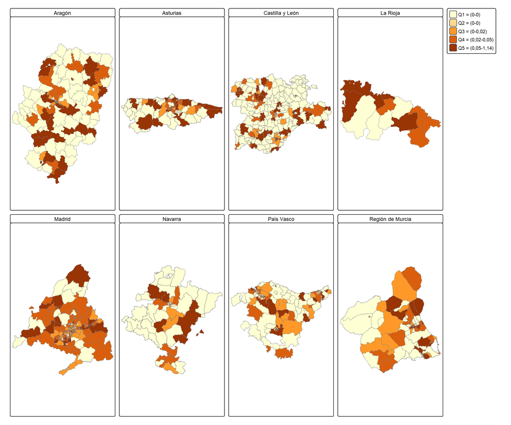

**Diazepinas, oxaxepinas y tiazepinas (N05AH)**

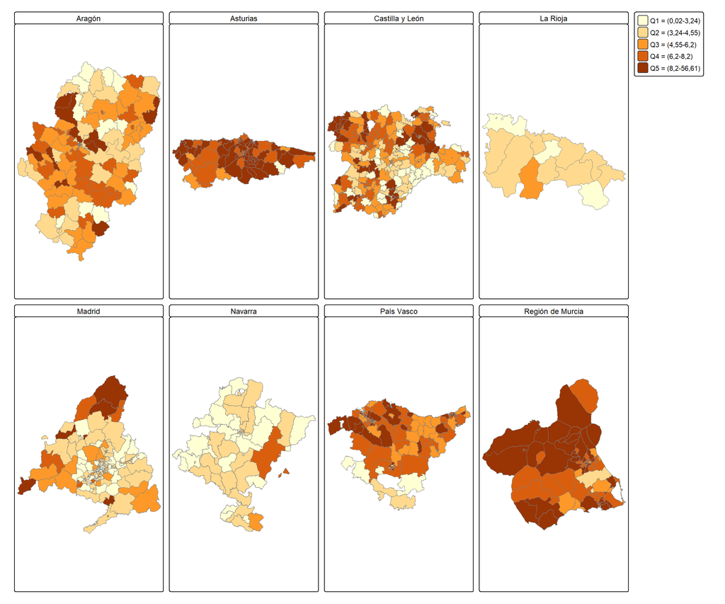

**Benzamidas (N05AL)**

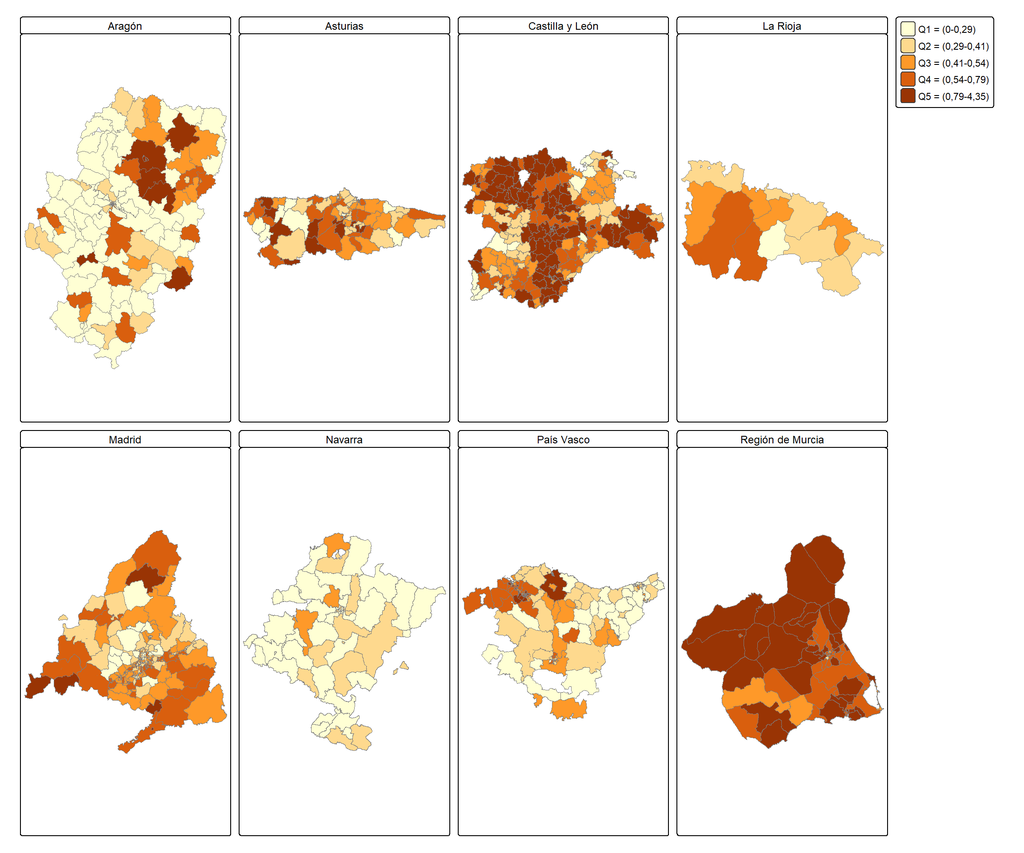

**Otros antipsicóticos (N05AX)**

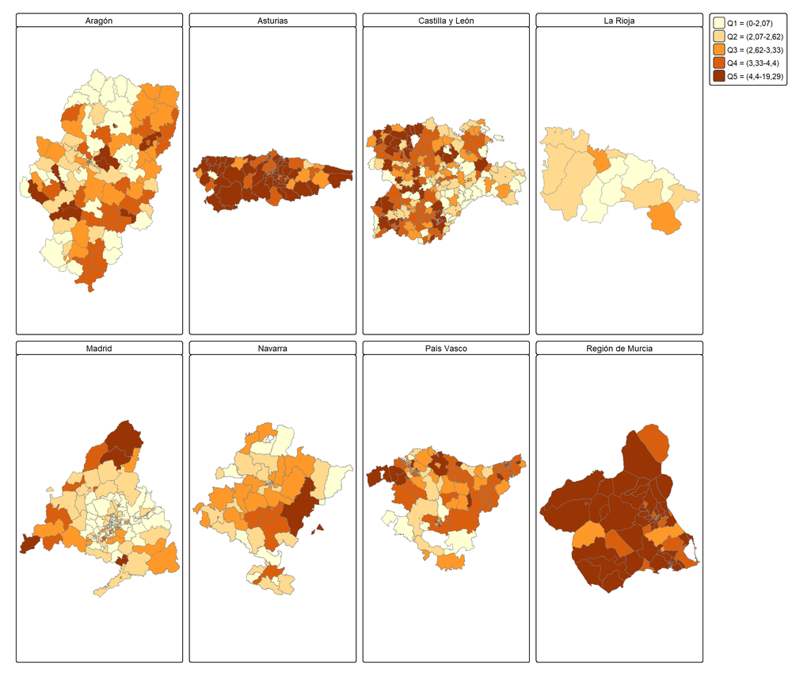

## Comparación de la variación de gasto (PVP) frente a variación de consumo (DHD)

**Descripción figura**

Se muestra el gasto PVP frente al consumo (DHD) donde para cada comunidad autónoma se calcula una regresión lineal en función de los valores calculados para cada ZBS para toda la serie temporal.

**Antipsicóticos (N05A)**

[interactive chart not shown]

**Fenotiazinas con cadena lateral alifática (N05AA)**

[interactive chart not shown]

**Fenotiazinas con estructura piperazínica (N05AB)**

[interactive chart not shown]

**Derivados de la butirofenona (N05AD)**

[interactive chart not shown]

**Derivados del indol (N05AE)**

[interactive chart not shown]

**Derivados del tioxanteno (N05AF)**

[interactive chart not shown]

**Derivados del difenilbutilpiperidina (N05AG)**

[interactive chart not shown]

**Diazepinas, oxaxepinas y tiazepinas (N05AH)**

[interactive chart not shown]

**Benzamidas (N05AL)**

[interactive chart not shown]

**Otros antipsicóticos (N05AX)**

[interactive chart not shown]

## Evolución temporal del porcentaje de envases de antipsicóticos depot vs no depot por CCAA

**Descripción figura**

Distribución porcentual anual de envases dispensados de antipsicóticos *depot* (liberación prolongada) frente a no *depot* (convencional) por CCAA. Para garantizar la comparabilidad, el denominador incluye únicamente aquellos códigos ATC para los que existe dispensación de formulaciones *depot* en el periodo analizado.

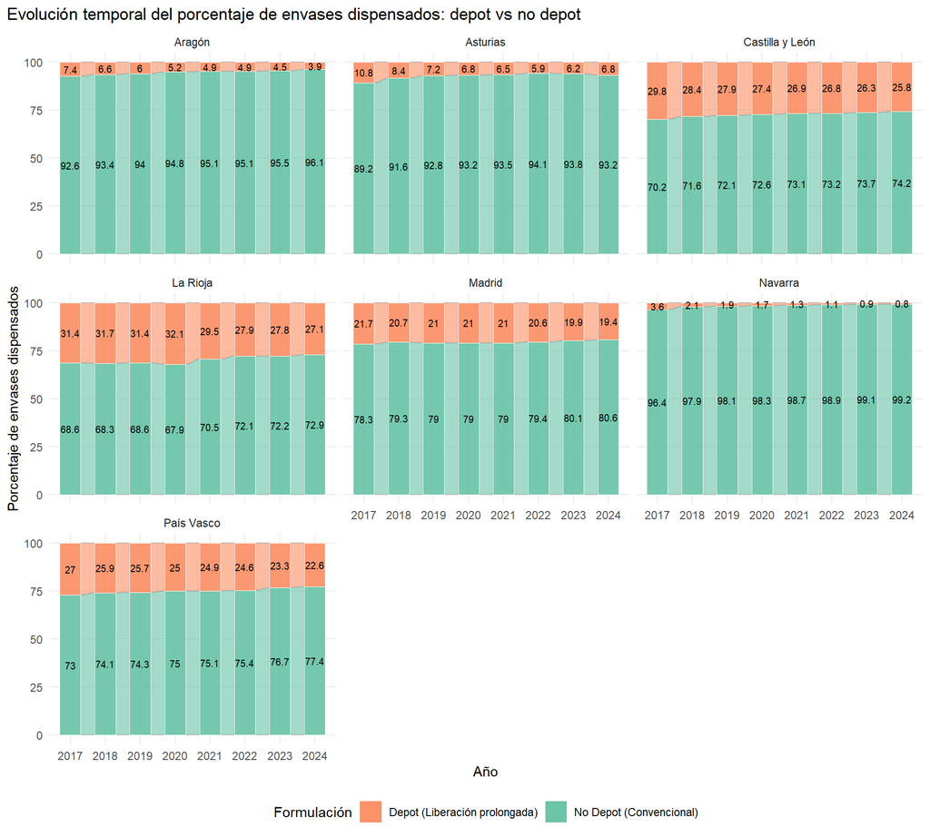

# Notas metodológicas

## Sobre los resultados analizados

Este informe se centra en el cálculo de las tasas estandarizadas para cada subgrupo terapéutico tomando como referencia la población española (población INE), por sexo y grupo quinquenal de edad, para cada año del periodo de estudio. Este informe restringe el periodo de estudio desde el 01 de enero de 2017 al 31 de diciembre de 2024. Los indicadores de consumo de medicamentos están calculados como Dosis por mil Habitantes Día (DHD), o como gasto (€) por habitante, utilizando como referencia la Dosis Diaria Definida (DDD) por envase de cada medicamento o el Precio de Venta al Público (PVP) disponibles en el [nomenclator de facturación de farmacia del Ministerio de Sanidad](https://www.sanidad.gob.es/profesionales/nomenclator.do) (descargado en Septiembre 2025) respectivamente.

- El número de envases dispensados por habitante se calcula como el
  $$\sum(envases_{ATC, ZBS})/población_{ZBS, sexo, grupo edad}$$
- Dosis por mil Habitantes Día (DHD) se calcula como el
  $$((\sum(DDD_{ATC}) * 1000_{habitantes})/ (población_{ZBS, sexo, grupo edad} * 365_{días}))$$
- El gasto (€) por habitante se calcula como
  $$Gasto = \sum(PVP)/(población_{ZBS, sexo, grupo edad})$$

## Sobre la unidad de análisis

La unidad de análisis en este informe son las zonas básicas de salud (ZBS) de referencia según la residencia de los pacientes dispensados.

## Sobre los indicadores

Los indicadores estudiados se corresponden con subgrupos de antipsicóticos en función de su código ATC, además de aquellos otros indicadores considerados relevantes para estudio por las comunidades autónomas participantes en este proyecto.

- Antipsicóticos (*N05A*),
- Subgrupo terapéutico:
  - Fenotiazinas con cadena lateral alifática (*N05AA*),
  - Fenotiazinas con estructura piperazínica (*N05AB*),
  - Fenotiazinas con estructura piperidínica (*N05AC*),
  - Derivados de la butirofenona (*N05AD*),
  - Derivados del indol (*N05AE*),
  - Derivados del tioxanteno (*N05AF*),
  - Derivados del difenilbutilpiperidina (*N05AG*),
  - Diazepinas, oxaxepinas y tiazepinas (*N05AH*),
  - Benzamidas (*N05AL*),
- Otros antipsicóticos (*N05AX*).

A continuación se muestra el listado de códigos de ATC que aparecen en los datos de entrada:

```
flowchart TD
A[N05A] --> B[N05AA]
    A --> C[N05AB]
    A --> D[N05AC]
    A --> E[N05AD]
    A --> F[N05AE]
    A --> G[N05AF]
    A --> H[N05AG]
    A --> I[N05AH]
    A --> J[N05AL]
    A --> K[N05AX]
    B --> L[N05AA01\nN05AA02]
    C --> M[N05AB03]
    D --> N[N05AC01]
    E --> O[N05AD01]
    F --> P[N05AE03\nN05AE04\nN05AE05]
    G --> Q[N05AF05]
    H --> R[N05AG02]
    I --> S[N05AH02\nN05AH03\nN05AH04\nN05AH05\nN05AH06]
    J --> T[N05AL01\nN05AL03\nN05AL05\nN05AL07]
    K --> U[N05AX08\nN05AX12\nN05AX13\nN05AX15\nN05AX16]
```

## Fuente de datos

Los registros de los envases dispensados han sido extraídos de acuerdo al modelo común de datos del Atlas de Farmacia a partir de la base de datos de dispensaciones (i.e., receta electrónica) o base de datos de facturación de farmacia (i.e., cinta de facturación de farmacia) de las CCAA participantes. Puede consultar el modelo común de datos en el [repositorio del proyecto](https://github.com/cienciadedatosysalud/atlas-farmacia).

## Sobre el numerador

Para el cálculo de los indicadores se utilizaron todos los envases dispensados de forma ambulatoria en oficina de farmacia de aquellos fármacos cuyo ATC se consideró relevante (i.e., antipsicóticos (*N05A*)) a pacientes con una tarjeta sanitaria activa en el momento de la dispensación independientemente de la necesidad de visado y de la patología o condición para la que fueran dispensados. Estos ATC no incluyen todos los antipsicóticos sino sólo aquellos seleccionados como relevantes para estudio.

| CCAA | Numerador | Fuente de información |
| --- | --- | --- |
| Aragón | Población residente en la CCAA y asignada a ZBS que tenga al menos una dispensación durante el periodo de estudio | Receta electrónica |
| Principado de Asturias | Población residente asignada a ZBS con al menos una dispensación | Receta electrónica |
| Castilla y León | Solo se incluyen recetas de pacientes de Castilla y León (tanto dentro como fuera de la CCAA si están prescritas en la CCAA) | Facturación farmacia ambulatoria |
| Comunidad de Madrid | Población residente asignada a ZBS con al menos una dispensación | Receta electrónica |
| Comunidad Foral de Navarra | Residentes en la CCAA adscritas a la ZBS (independientemente del profesional del SNS-O que la realiza) | Receta electrónica |
| País Vasco | Población TIS con tarjeta sanitaria adscrita a un ZBS de la CCAA | Receta electrónica |
| La Rioja | Sólo residentes en la CCAA con tarjeta sanitaria adscrita a una ZBS de la CCAA | Receta electrónica |
| Región de Murcia | Población residente asignada a ZBS con al menos una dispensación | Receta electrónica |

## Sobre el denominador

Los envases dispensados se asignan a la ZBS relativa al área de residencia del paciente. De esta manera, el análisis realizado compara el consumo farmacéutico o la exposición de las poblaciones a estos fármacos según su lugar de residencia. La población utilizada en la estandarización y cálculo de los denominadores de los indicadores procede de la actualización anual de población con tarjeta sanitaria del conjunto de todas las CCAA durante el periodo de estudio.

## Sobre la metodología de análisis

Este informe se basa en la compilación y meta-análisis de resultados agregados generados por cada CCAA participante de forma federada, mediante la ejecución de análisis locales reproducibles. Este informe es el primer AtlasVPM realizado de forma federada. Las CCAA han participado en este AtlasVPM desplegando un entorno analítico reproducible (i.e., contendor Docker) conteniendo los análisis estadísticos locales para la generación de resultados agregados y compartiendo estos resultados con el grupo de Ciencia de Datos para la Investigación en Servicios y Políticas de Salud en el Instituto Aragonés de Ciencias de la Salud (IACS).

# Contribuciones

[figure not shown]

Aragón

Francisco Estupiñán Romero, Javier González Galindo, Santiago Royo Sierra, Natalia Martínez Lizaga, Miriam Seral Rodríguez, Ramón Launa Garcés, Ester Angulo Pueyo, Manolo Ridao López, Enrique Bernal Delgado

Instituto Aragonés de Ciencias de Salud

[figure not shown]

Principado de Asturias

Gracia M Modroño Riaño

Servicio de Salud del Principado de Asturias

[figure not shown]

Islas Baleares

Eusebi Castaño Riera, María Zaforteza Dezcallar, María Jesús Martín Sánchez

Consejería de Salud y Consumo

[figure not shown]

Cantabria

María Ángeles Lumbreras, Flora Pérez Hernández, Óscar Valcuende Mantilla

Dirección General de Ordenación Sanitaria, Farmacia e Inspección

[figure not shown]

Cataluña

Cristina Colls Guerra, Mireia Espallargues Carreras, Érica Martínez Solanas, Manuel Medina Peralta, Andrea Molina Nadal, Pere Carbonell Puigdollers, Montserrat Vicente Belis

Agència de Qualitat i Avaluació Sanitàries de Catalunya (AQUAS). Servei Català de la Salut. Consorci Sanitari de Barcelona

[figure not shown]

Canarias

Jose Miguel Rodríguez Lugo, Sara Trujillo Alemán

Servicio de Evaluación de la Calidad Asistencial y Sistemas de Información de la Dirección General de Programas Asistenciales

[figure not shown]

Castilla y León

Alejandra García Ortíz, Judith Ceruelo Bermejo, Nieves Martín Sobrino, Juan Carlos Solsona Perea

Dirección Técnica de Farmacia. Gerencia Regional de Salud de Castilla y León

[figure not shown]

Comunidad Valenciana

Julia Calabuig

Conselleria de Sanitat

[figure not shown]

Comunidad de Madrid

José Manuel Izquierdo Palomares, Ángel Luis Mataix Sanjuan, María Isabel del Cura González, Tamara Alonso Safont

Gerencia Asistencial de Atención Primaria

[figure not shown]

Comunidad Foral de Navarra

Maite Almirantearena Legaz, Anabel Zaborras Aguado, Javier Gorricho Mendívil

Servicio Navarro de Salud - Osasunbidea (SNS-O)

[figure not shown]

País Vasco

Eduardo Millán Ortuondo, Ricardo Samper Ochotorena

Osakidetza

[figure not shown]

La Rioja

Felix Rivera Sanz, Pilar Sáenz Ortiz, Jose María Rodríguez Corral

Rioja Salud

[figure not shown]

Región de Murcia

Carlos Arenas Díaz, Víctor Rausell, José Eduardo Calle Urra, Amaya Jimeno Almazán, Rafael Herrero Delicado, Mariana Tobaruela Soto, María Onteniente Candela

Servicio Murciano de Salud

# Referencias

- [Atlas de variaciones injustificadas de la práctica médica (Atlas VPM)](https://cienciadedatosysalud.org/)
- [Repositorio GitHub *Atlas Farmacia* del grupo de Ciencia de datos para la investigación en servicios y políticas sanitarias](https://github.com/cienciadedatosysalud/atlas-farmacia)
- [Red de Investigación en Cronicidad, Atención Primaria y Prevención y Promoción de la Salud (RICAPPS)](https://www.ricapps.es/)